# Regione_di_credibilita

NikolayNikolaev

2023-05-29

## Regione di credibilità

Quando la regione di credibilita viene determinata considerando intervalli entrali fissando $\alpha=0.05$ l’intervallo ha come estremi i quantili di ordine $1-\alpha /2$ and $\alpha/2$ della distribuzione a posteriori

##Esempio 1: Si supponga di osservare delle realizzazioni in 10 unità campionarie assunte come determinazioni indipendenti da una variabile casuale di Bernoulli. Si contano in totale due successi. Assumendo il modello Beta-Binomiale e una distribuzione a priori non informativa per la probabilità di successo $p=Beta(1,1)$, la distribuzione e’ uniforme e pertanto la distribuzione a posteriori e’ la seguente $p(\theta|x) = Beta(1+2, 1+8)$

L’intervallo di credibilita centrale al livello di credebilita del %95%$ si determina considerando i quantili.

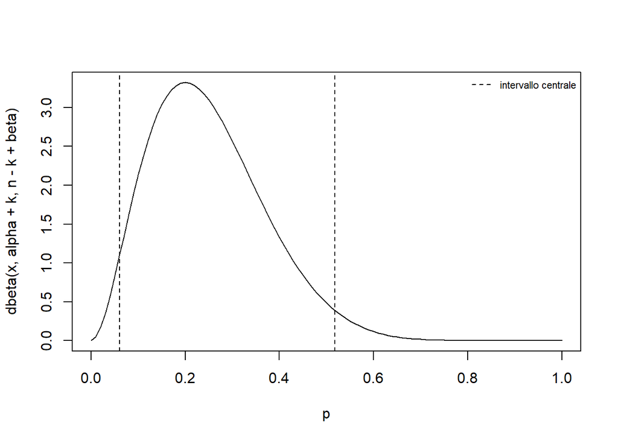

```r
alpha<-beta <-1
n <- 10
k <- 2
curve(dbeta(x, alpha+k, n-k+beta), xlab = "p")
ci <- qbeta(c(0.025, 0.975), alpha+k, n-k+beta)
abline(v = ci, lty=2)
legend("topright",
       "intervallo centrale",
       lty = 2,
       bty = "n",
       cex = 0.7)
```

Gli estremi dell’intervallo di credibilità al 95% sono i seguenti
$$[0.06, 0.52]$$

Si nota che l’intervallo è particolarmente ampio e pertanto l’accuratezza della stima non è elevata.

## Esempio 2:

Nel seguito si utilizza l’esempio illustrato in precedenza circa il numero di ipertesi dove sono state definite diverse distribuzioni a priori Beta.

```r
ci <- qbeta(c(0.025,0.975),13.5,7.5); ci
```

```
## [1] 0.4322339 0.8277238
```

Questi estremi definiscono la regione di credibilità al 95% per la proporzione di soggetti ipertesi nella popolazione.

La seguente figura mostra la distribuzione a posteriori e l’intervallo di credibilità al 95% per il parametro ricavato in precedenza.

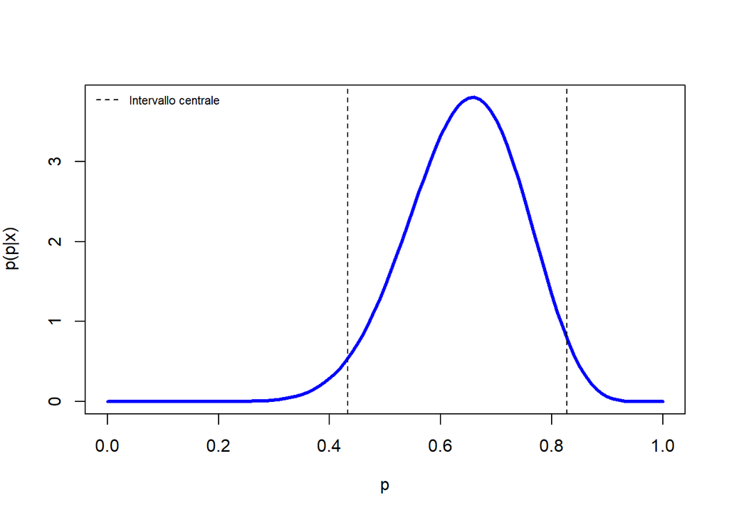

```r
curve(dbeta(x,13.5,7.5),
      ylab=expression(paste(p,"(",p,"|x)")),
      xlab=expression(p),
      col ="blue",
      lwd = 3)
abline(v=ci,lty=2)
legend("topleft",
      "Intervallo centrale",
      lty=2,
      bty="n",
      cex=0.7)
```

Si noti che ci sono valori del paramertro al di fuori dell’intervallo basato sul quantile che hanno una densità maggiore di alcuni punti all’interno dell’intervallo. ## Intervallo con la massima densità a posteriori Questo intervallo ha la caratteristica come il precedente di contenere sempre il $100(\alpha/2)$% della distribuzione a posteriori ed inoltre la densità in questa regione non è mai inferiore di quella esterna alla regione. Per determinare l’intervallo di credibilità considerando la massima densità a posteriori occorre applicare metodi numerici per massimizzare la funzione con il metodo di Lagrange. Nel seguito ci si avvale della funzione binom.bayes della libreria binom che implementa il metodo e restituisce l’intervallo ed il grafico della densità a posteriori.

```r
require(binom)
hpd<-binom.bayes(13, 20,
                 conf.level = 0.95,
                 type = c("highest"),
                 prior.shape1 = 0.5,
                 prior.shape2 = 0.5,
                 tol = .Machine$double.eps^0.5)
print(hpd)
```

```
##   method  x  n shape1 shape2      mean     lower     upper        sig
## 1  bayes 13 20   13.5    7.5 0.6428571 0.4423068 0.8360884 0.04999999
```

Utilizziamo la funzione binom.bayes.densityplot per rappresentare graficamente l’area riferita alla massima densità a posteriori

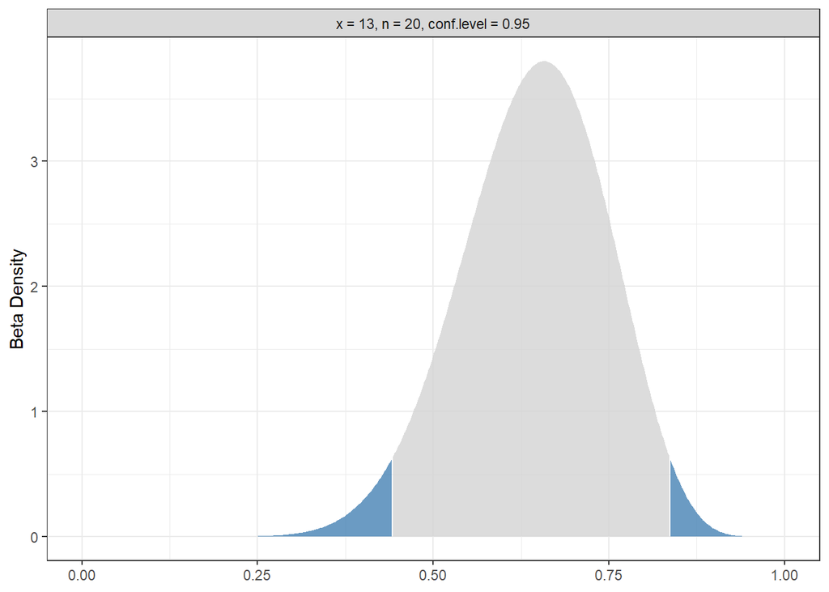

```r
binom.bayes.densityplot(hpd)
```

## Rappresentazione grafica

```r
c1<-0.44
c2 <-0.84
(13.5-1)/(13.5+7.5-2)
```

```
## [1] 0.6578947
```

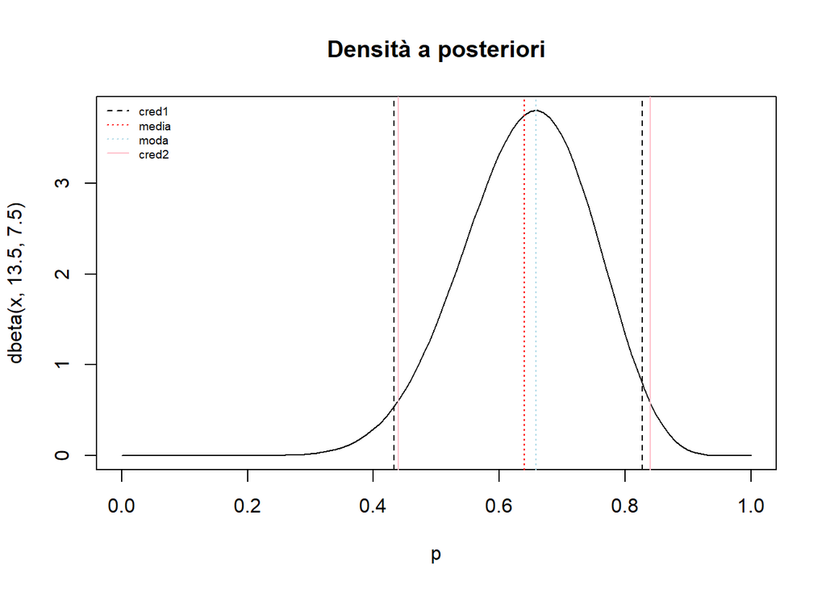

```r
curve(dbeta(x,13.5,7.5),
      main = "Densità a posteriori", xlab = "p")
abline(v=ci,lty=2)
abline(v=0.64, lty = 3, col = "red")
abline(v=0.6579, lty = 3, col = "lightblue")
abline(v=c(c1,c2),lty=1, col="pink")
legend("topleft",
       c("cred1","media", "moda", "cred2"),
       lty=c(2,3,3,1), bty="n",cex=0.6,
       col = c("black","red", "lightblue", "pink"))
```